# Introduction to 21019 homework

Hao Liang

2021-12-20

## HW0

### Question

Use knitr to produce at least 3 examples(texts, figures and tables).

### Answer

#### Text

示例文本如下:

$\frac{1}{n}\sum_{i=1}^{n}(x_i-\bar{x})^2=\frac{1}{n}\sum_{i=1}^{n}x_i^2-\bar{x}^2$

即样本的方差等于样本平方的均值减去均值的平方。

#### Figures

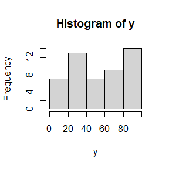

```r
#生成100以内正整数简单随机不放回抽样50例，记为y，x为1至50的自然数
set.seed(0)
x=1:50
y= sample(1:100,size=50,replace = F)


#生成y的直方图
hist(y)
```

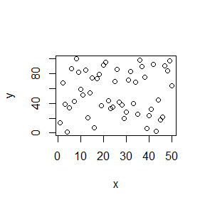

```r
#生成x,y的散点图
plot(x,y)
```

#### Tables

```r
#生成x和y的一元线性回归模型
model<-lm(x~y)

#输出统计量表格
knitr::kable(summary(model)$coef)
```

|  | Estimate | Std. Error | t value | Pr(>\|t\|) |
| --- | --- | --- | --- | --- |
| (Intercept) | 24.3687583 | 4.3664431 | 5.5809175 | 0.0000011 |
| y | 0.0207796 | 0.0705113 | 0.2946989 | 0.7694947 |

## HW1

### 题3.4

The Rayleigh density [156,Ch.18] is

$$f(x)=\frac{x}{\sigma^2}e^{-x^2/(2\sigma^2)},\qquad x\geq0,\sigma>0.$$
Develop an algorithm to generate random samples from a Rayleigh($\sigma$) distribution. Generate Rayleigh($\sigma$) samples for several choices of $\sigma$> 0 and check that the mode of the generated samples is close to the theoretical mode $\sigma$ (check the histogram).

分布函数

$$\begin{aligned}
F_X(x)=&\int_{0}^xf(y)dy\\
=&\int_{0}^x\frac{y}{\sigma^2}e^{-y^2/(2\sigma^2)}dy\\
=&1-e^{-x^2/(2\sigma^2)}
\end{aligned}$$

考虑分布函数的反函数
$$\begin{aligned}
F_X^{-1}(U)=\sqrt{-2\sigma^2ln(1-U)}
\end{aligned}$$

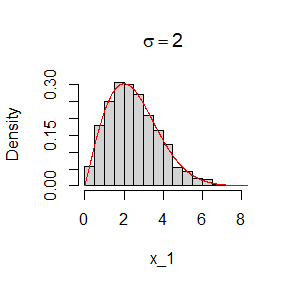

```r
set.seed(123)
n<-1000
u<-runif(n)
y<-seq(0,20,.01)

#par(mfrow=c(1,2))
#sigma=2的情形，可以看出拟合较好
sig_1<-2


x_1<-sqrt(-2*sig_1^2*log(1-u))
hist(x_1,probability = T,main=expression(sigma==2))
#添加理论密度曲线,图中为红线
lines(y,y/sig_1^2*exp(-y^2/(2*sig_1^2)),col="red")
```

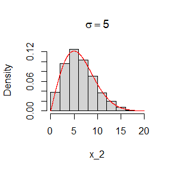

```r
#sigma=5的情形，可以看出拟合较好
sig_2<-5

x_2<-sqrt(-2*sig_2^2*log(1-u))
hist(x_2,probability = T,main=expression(sigma==5))
#添加理论密度曲线,图中为红线

lines(y,y/sig_2^2*exp(-y^2/(2*sig_2^2)),col="red")
```